# Why Tidyverse is just awesome!

June 15, 2017

## Why do R need Tidyverse?

## The basics

- R is Open Source
- R is an old language – first appeared in 1993
- R is based on S which is even older – first build in 1976
- Easy to build and expand upon with packages
- Now more than 10.000 packages

## Consequences

- Open Source + Old = Lots of contributors over time
- Lots of contributers + Old = Lots of old code and lots of different coding paradigms
- = Rather difficult to (really) learn from scratch

## But why is R so popular then?

- For me:
- My tool of choice because it (in my opinion) focuses on the important part of the domain – data science itself.
- Data Science vs. Programming
- …and then there also those 10.000 packages!
- …and all that PhD research baked into new R packages!

## The force driving Tidyverse

## Enter Hadley Wickham…

- A man with a course!
- “You should behave responsibly R-wise!”
- “You should embrace modern engineering practices!”
- “You should use R as it was intended!”
- “You should respect your peers – and all other human beings!”
- [ The above = my take on what drives the guy… ]

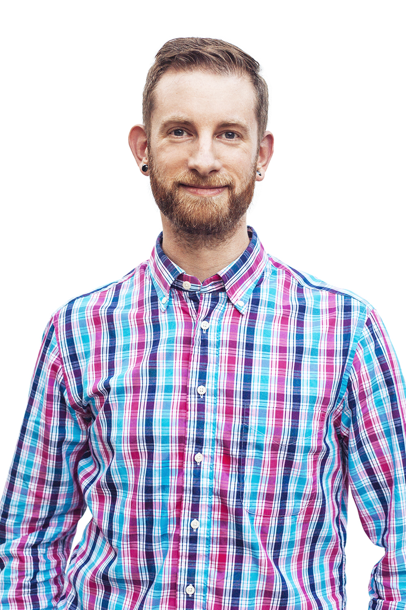

## Hadleys own take on the "Tidy Tools Manifesto"

- “Share data structures”
- “Compose simple pieces”
- “Embrace Functional Programming”
- “Write for humans”
- [ [https://speakerdeck.com/hadley/tidyverse](https://speakerdeck.com/hadley/tidyverse?slide=8) ]

## Ok – but what is this Tidyverse?

## Tidyverse – random facts

- Focuses on the way data scientists think and work
- Started out as “Hadleyverse”
- Officially changed name to Tidyverse, [Oct. 2016](https://github.com/rocker-org/rocker/issues/201)
- Great for beginners and experts alike
- A collection of consistent R packages supporting a systematic Data Science workflow.

## Tidyverse – ordered by function

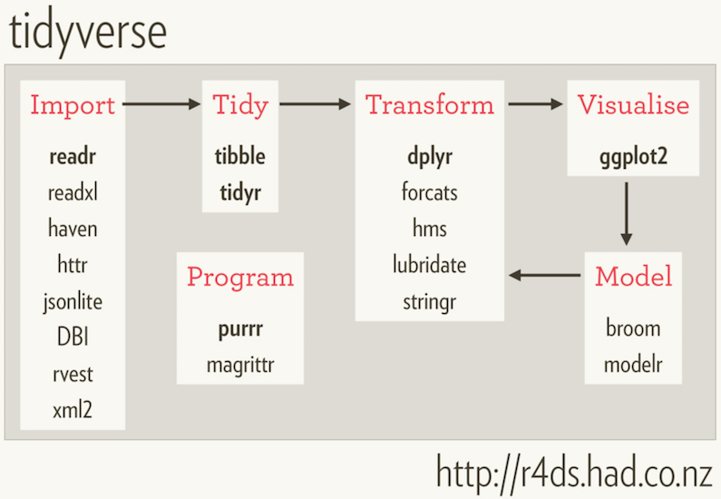

## Tidyverse – by usage

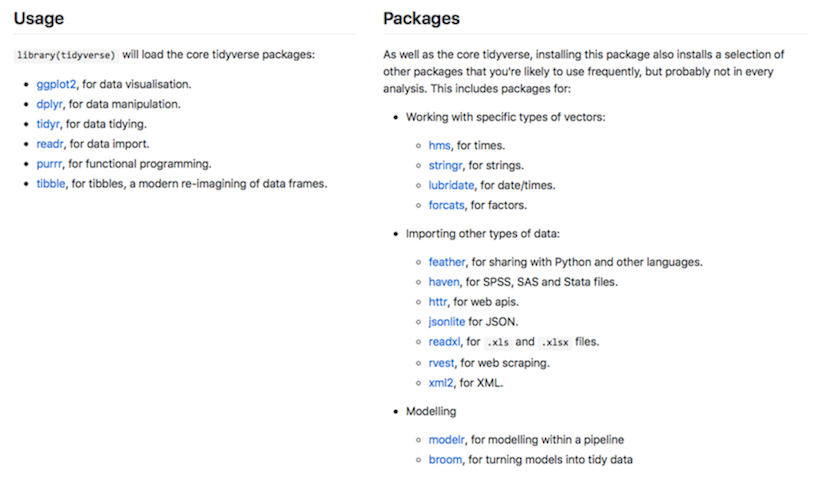

From: github.com/tidyverse/tidyverse

## Tidyverse – Beginners vs. advanced

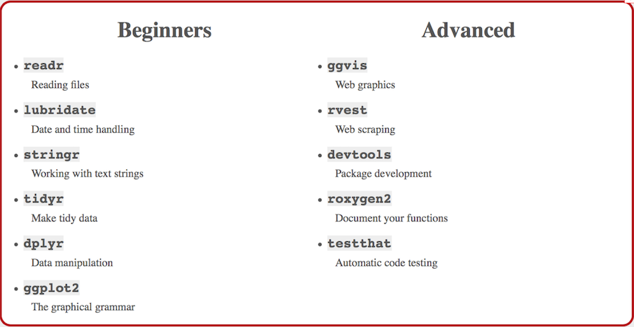

From barryrowlingson.github.io/hadleyverse/#4

## Show me the code!

## My top 10 favorite Tidyverse tricks

## Use lists whenever possible

[ Demo ]

(Tip: See slideshow code for details.)

## …and explore the lists interactively

```r
View(outputTables[["INITIALIZE"]])

View(outputTables[["STOP"]])
```

## Use readr for fileinput – and exploration

- readr is integrated into RStudios file navigation
- [ Demo ]

(Tip: See slideshow code for details.)

## Use httr for APIs

```r
library(httr)
library(jsonlite)

spotifyOAuth <- function(app_id, client_id, client_secret) {
    spotifyR <- httr::oauth_endpoint(
        authorize = "https://accounts.spotify.com/authorize",
        access = "https://accounts.spotify.com/api/token")
    myapp <- httr::oauth_app(app_id, client_id, client_secret)
    return(httr::oauth2.0_token(spotifyR, myapp, scope = "playlist-modify-public"))
}

keys <- spotifyOAuth("roskilde-2017",
                     "your_client_id",
                     "your_client_secret")
```

## …and get the data

```r
searchArtist <- function(artistName) {
    r <- httr::RETRY("GET", paste0("https://api.spotify.com/v1/search?q=",
                                   gsub(' ', '+', artistName),"&type=artist&market=DK"),
                     times = 30)
    req <- jsonlite::fromJSON(content(r, "text"))
    if (!is.null(req$artists$total) && req$artists$total > 0) {
        artist <- req$artists$items[,c("id", "name", "popularity", "genres", "type")]
        artist$followers <- as.numeric(req$artists$items$followers$total)
        return(artist)
    } else {
        return(NA)
    }
}

sp_artists_raw <- lapply(rf_artists$encodedName, searchArtist)
```

## Use tibble for more reable code

[ Demo - Roskilde Festival ]

(Tip: See slideshow code for details.)

## Use map, map2 and pmap from purrr instead of apply, sapply, mapply etc.

```r
n <- list(1, 3, 5)
args1 <- list(n, mu, sigma)
args1 %>%
    pmap(rnorm) %>%
    str()

map
map_lgl
map_chr
map_int
map_dbl
map_df
walk
```

## Use dplyr and tidyr for your data pipeline

```r
library(gapminder)
library(tidyr)
library(dplyr)

View(gapminder)

by_country <- gapminder %>%
    mutate(year1950 = year - 1950) %>%
    group_by(continent, country) %>%
    nest()

View(by_country)
```

[ Gapminder Demo ]

## Use purrr::map for your data pipeline

```r
library(purrr)

country_model <- function(df) {
    lm(lifeExp ~ year1950, data = df)
}

by_country2 <- by_country %>%
    mutate(model = map(data, country_model))

View(by_country2)
```

[ Demo - cont. ]

## Use modelr for your data pipeline

```r
library(modelr)

by_country3 <- by_country2 %>%
    mutate(resids = map2(data, model, add_residuals))

View(by_country3)
```

[ Demo - cont. ]

## Use ggplot2 for your data pipeline

```r
library(ggplot2)

unnest(by_country3, resids) %>%
    ggplot(aes(year, resid, group = country)) +
    geom_line(alpha = 1 / 3) + facet_wrap(~continent)
```

[ Demo - cont. ]

## Remember: Tidyverse needs Tidy data

- Each variable forms a column.
- Each observation forms a row.
- Each type of observational unit forms a table.
- [ From [Tidy Data](http://vita.had.co.nz/papers/tidy-data.pdf) by Hadley Wickham ]

## I want all this Tidy Goodness!!! Where do I start?

## Hadleys Wickhams talk at Plotcon 2016, New York (30:00 min)

[figure not shown]

Link: [youtube.com](https://youtu.be/cU0-NrUxRw4?t=1s)

## R for Data Science (book) – great introduction to Data Science and Tidyverse.

[figure not shown]

From http://r4ds.had.co.nz

## RStudio Webinars (videos)

[figure not shown]

Link: rstudio.com/resources/webinars/

## Advanced R (book) – great introduction to R as a full fledged Functional Programming language.

[figure not shown]

From http://adv-r.had.co.nz

## R Cheatsheets by RStudio (pdf) – great for easy reference to main packages.

[figure not shown]

Link: rstudio.com/resources/cheatsheets/

## Still not convinced?!

## Don’t take my word for it – other people are fans too!

*“The Hadleyverse is where we want to be!”*

Andrew Gelman  
Prof. Columbia University  
#1 STAN Core Developer  
(among other things)

[figure not shown]

## So wether you like it or not…

- Beware:
- Tidyverse is coming to a R galaxy near you!
- (and you really should embrace it)
- :-D

## Thanks!

- Niels Ole Dam
- Things in Flow
- @nielsoledam
- info@thingsinflow.dk
- https://thingsinflow.dk

Github repo with the code for this slideshow:  
http://bit.ly/why-tidyverse-is-just-awesome